# R Notebook

The researchers induced kidney injury in mice using bilateral ischemia-reperfusion injury (Bi-IRI), which essentially cuts off blood flow to both kidneys using clamps, then restores it. This mimics the kind of kidney injury that can occur in surgical or clinical settings.

Tissue and blood were collected at multiple points: a sham control, then 4 hours, 12 hours, 2 days, and 6 weeks after injury. This allowed the team to track the full arc of injury and repair.

In a sham procedure, the mice go through the entire surgical process, they’re anesthetized, cut open, and the kidneys are exposed, but the renal clamps are never actually applied. So blood flow to the kidneys is never interrupted, meaning no actual injury occurs.

We are comparing between sham and the 12 hours after surgery. At the 12 hour time point where they measured creatinine and GFR specifically, because that’s when kidney function loss is most clearly detectable in the blood.

Males are more susceptible to this injury. Clamp time would also be 22 minutes rather than 34 minutes for equivalent injury (the paper focuses more on females)

Cell Types to Focus On:

Injured Proximal Tubule cells - primary injury target

Macrophages - key immune responder at 12 hours

T cells - secondary immune response

Proximal Tubule Segments 1-3 (PTS1, PTS2, PTS3) - to see healthy vs injured tubule changes

Fibroblasts - early fibrotic signals

```r
library(STdeconvolve)
library(ggplot2)
library(patchwork)
library(ggrepel)
library(dplyr)
library(scatterbar)
```

```r
sham <- read.csv('C:/Users/lilli/Desktop/visium_male_kidney_shamecontrol.csv.gz')
hour12 <- read.csv('C:/Users/lilli/Desktop/visium_male_kidney_AKI_12hrecovery.csv.gz')
hour4 <- read.csv('C:/Users/lilli/Desktop/visium_male_kidney_AKI_4hrecovery.csv.gz')
```

```r
pos_sham <- sham[, c('X','Y')]
gexp_sham <- sham[, 4:ncol(sham)]
pos_hour12<- hour12[, c('X','Y')]
gexp_hour12 <- hour12[, 4:ncol(hour12)]
pos_hour4<- hour4[, c('X','Y')]
gexp_hour4 <- hour4[, 4:ncol(hour4)]
```

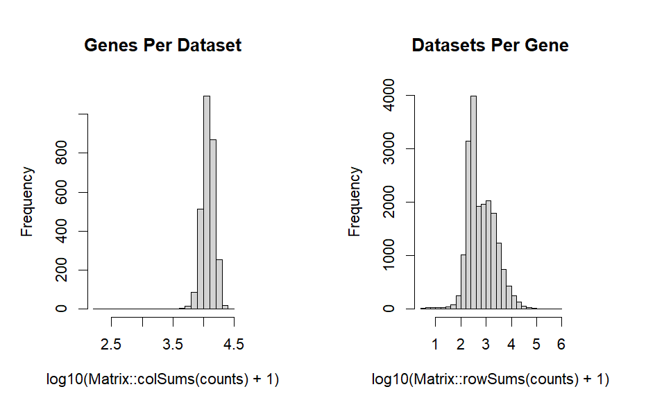

```r
#gexp is in spots x genes format; cleanCounts expects genes x spots, so we transpose.
counts_sham <- cleanCounts(t(gexp_sham), min.lib.size = 100, verbose = TRUE, plot = TRUE)
```

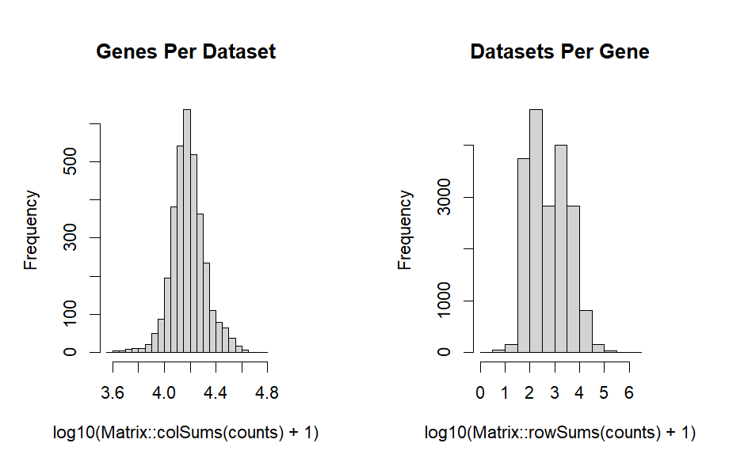

```r
counts_hour12 <- cleanCounts(t(gexp_hour12), min.lib.size = 100, verbose = TRUE, plot = TRUE)
```

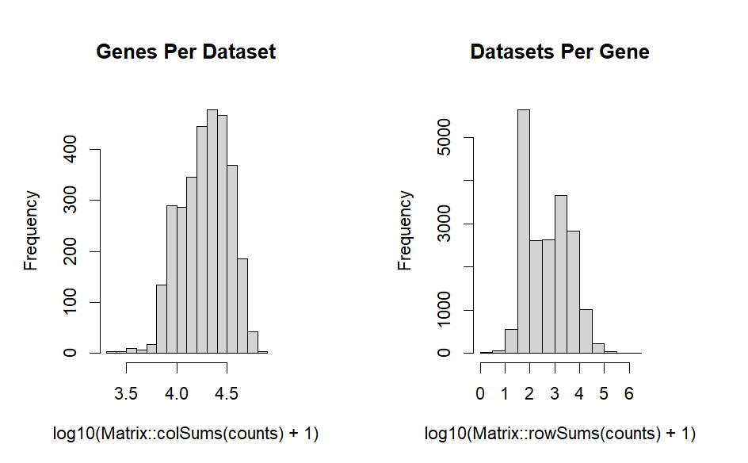

```r
counts_hour4 <- cleanCounts(t(gexp_hour4), min.lib.size = 100, verbose = TRUE, plot = TRUE)
```

```r
#feature selection for genes
# corpus will be a matrix with genes as rows and spots as columns.
corpus_sham <- restrictCorpus(counts_sham, removeAbove = 1.0, removeBelow = 0.05, nTopOD = 1000)
corpus_hour12 <- restrictCorpus(counts_hour12, removeAbove = 1.0, removeBelow = 0.05, nTopOD = 1000)
corpus_hour4 <- restrictCorpus(counts_hour4, removeAbove = 1.0, removeBelow = 0.05, nTopOD = 1000)
```

```r
fitLDA(t(as.matrix(corpus_sham)), Ks = seq(2, 9, by = 1),
               perc.rare.thresh = 0.05,
               plot=TRUE,
               verbose=TRUE)
```

```
now fitting LDA model with K = 2
now fitting LDA model with K = 3
now fitting LDA model with K = 4
now fitting LDA model with K = 5
now fitting LDA model with K = 6
now fitting LDA model with K = 7
now fitting LDA model with K = 8
now fitting LDA model with K = 9
computing perplexity for LDA model with K = 2
computing perplexity for LDA model with K = 3
computing perplexity for LDA model with K = 4
computing perplexity for LDA model with K = 5
computing perplexity for LDA model with K = 6
computing perplexity for LDA model with K = 7
computing perplexity for LDA model with K = 8
computing perplexity for LDA model with K = 9
$models
$models$`2`
A LDA_VEM topic model with 2 topics.

$models$`3`
A LDA_VEM topic model with 3 topics.

$models$`4`
A LDA_VEM topic model with 4 topics.

$models$`5`
A LDA_VEM topic model with 5 topics.

$models$`6`
A LDA_VEM topic model with 6 topics.

$models$`7`
A LDA_VEM topic model with 7 topics.

$models$`8`
A LDA_VEM topic model with 8 topics.

$models$`9`
A LDA_VEM topic model with 9 topics.


$kneedOptK
[1] 3

$minOptK
[1] 8

$ctPropOptK
[1] 7

$numRare
[1] 0 0 0 0 0 0 1 1

$perplexities
[1] 329.5938 309.2937 301.7601 301.9928 301.3916 300.2351 299.7471 299.7607

$fitCorpus
A 2857x810 simple triplet matrix.

$testCorpus
A 2857x810 simple triplet matrix.
```

```
now fitting LDA model with K = 2
now fitting LDA model with K = 3
now fitting LDA model with K = 4
now fitting LDA model with K = 5
now fitting LDA model with K = 6
now fitting LDA model with K = 7
now fitting LDA model with K = 8
now fitting LDA model with K = 9
computing perplexity for LDA model with K = 2
computing perplexity for LDA model with K = 3
computing perplexity for LDA model with K = 4
computing perplexity for LDA model with K = 5
computing perplexity for LDA model with K = 6
computing perplexity for LDA model with K = 7
computing perplexity for LDA model with K = 8
computing perplexity for LDA model with K = 9
$models
$models$`2`
A LDA_VEM topic model with 2 topics.

$models$`3`
A LDA_VEM topic model with 3 topics.

$models$`4`
A LDA_VEM topic model with 4 topics.

$models$`5`
A LDA_VEM topic model with 5 topics.

$models$`6`
A LDA_VEM topic model with 6 topics.

$models$`7`
A LDA_VEM topic model with 7 topics.

$models$`8`
A LDA_VEM topic model with 8 topics.

$models$`9`
A LDA_VEM topic model with 9 topics.


$kneedOptK
[1] 3

$minOptK
[1] 9

$ctPropOptK
[1] 8

$numRare
[1] 0 0 0 0 0 0 0 1

$perplexities
[1] 446.7995 397.1028 386.2931 381.3621 378.5995 376.7263 377.4440 376.7030

$fitCorpus
A 3085x1000 simple triplet matrix.

$testCorpus
A 3085x1000 simple triplet matrix.
```

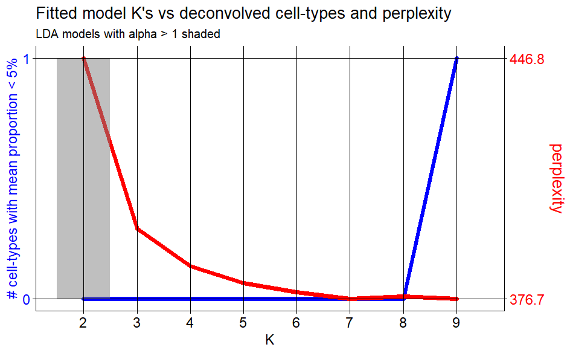

```r
fitLDA(t(as.matrix(corpus_hour4)), Ks = seq(2, 9, by = 1),
               perc.rare.thresh = 0.05,
               plot=TRUE,
               verbose=TRUE)
```

```
now fitting LDA model with K = 2
now fitting LDA model with K = 3
now fitting LDA model with K = 4
now fitting LDA model with K = 5
now fitting LDA model with K = 6
now fitting LDA model with K = 7
now fitting LDA model with K = 8
now fitting LDA model with K = 9
computing perplexity for LDA model with K = 2
computing perplexity for LDA model with K = 3
computing perplexity for LDA model with K = 4
computing perplexity for LDA model with K = 5
computing perplexity for LDA model with K = 6
computing perplexity for LDA model with K = 7
computing perplexity for LDA model with K = 8
computing perplexity for LDA model with K = 9
$models
$models$`2`
A LDA_VEM topic model with 2 topics.

$models$`3`
A LDA_VEM topic model with 3 topics.

$models$`4`
A LDA_VEM topic model with 4 topics.

$models$`5`
A LDA_VEM topic model with 5 topics.

$models$`6`
A LDA_VEM topic model with 6 topics.

$models$`7`
A LDA_VEM topic model with 7 topics.

$models$`8`
A LDA_VEM topic model with 8 topics.

$models$`9`
A LDA_VEM topic model with 9 topics.


$kneedOptK
[1] 3

$minOptK
[1] 9

$ctPropOptK
[1] 8

$numRare
[1] 0 0 0 0 0 0 0 1

$perplexities
[1] 389.3458 368.3908 361.5098 357.3187 359.4536 356.2621 355.4031 354.5684

$fitCorpus
A 3392x1000 simple triplet matrix.

$testCorpus
A 3392x1000 simple triplet matrix.
```

[figure not shown]

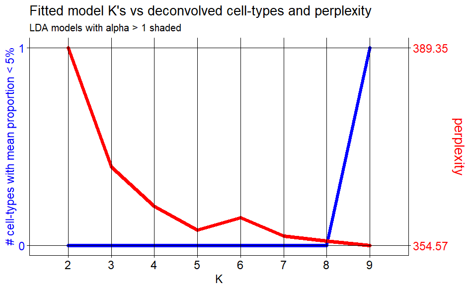

```r
fitLDA(t(as.matrix(corpus_hour12)), Ks = seq(2, 9, by = 1),
               perc.rare.thresh = 0.05,
               plot=TRUE,
               verbose=TRUE)
```

```r
# Rename columns using dplyr
pos_sham <- pos_sham %>% rename(x=X, y=Y)
pos_hour12 <- pos_hour12 %>% rename(x=X, y=Y)
pos_hour4 <- pos_hour4 %>% rename(x=X, y=Y)
```

```
now fitting LDA model with K = 7
computing perplexity for LDA model with K = 7
```

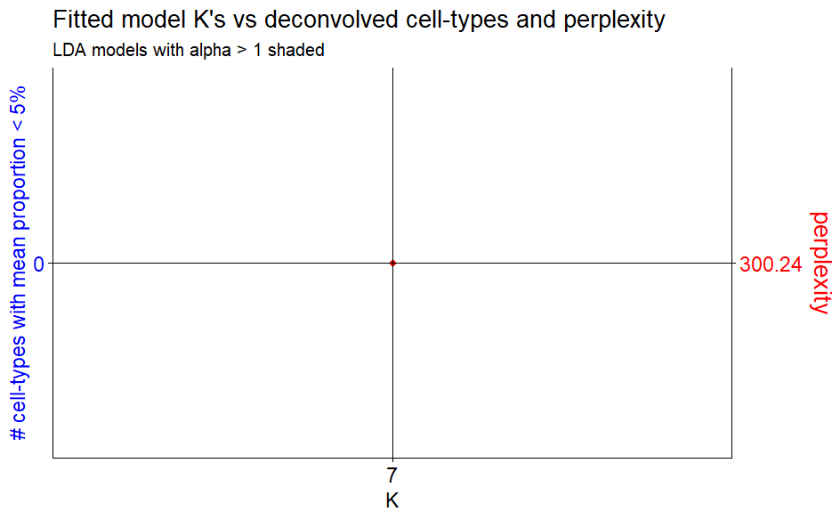

```r
#fit LDA models across a range of K values (number of cell types)
#fitLDA expects spots in rows and genes in columns, so we transpose corpus.
ldas_sham <- fitLDA(t(as.matrix(corpus_sham)), Ks = 7)
```

```r
#opting for K = 7
optLDA_sham <- optimalModel(models = ldas_sham, opt = "7")

#extract deconvolved cell-type proportions (theta) and transcriptional profiles (beta)
results_sham <- getBetaTheta(optLDA_sham, perc.filt = 0.05, betaScale = 1000)
deconProp_sham <- results_sham$theta  # Spots x cell types (clusters)
deconGexp_sham <- results_sham$beta   # Genes x cell types (clusters)

#scatterbar to create a scattered stacked bar chart
p_deconvolve_sham <- scatterbar(
  data         = as.data.frame(deconProp_sham),
  xy           = pos_sham,
  size_x       = 10,       # adjust to control bar width in x dimension
  size_y       = 10,       # adjust to control bar height in y dimension
  padding_x    = 0.01,     # add some padding to the x axis
  padding_y    = 0.01,     # add some padding to the y axis
  show_legend  = TRUE,
  legend_title = "Cell Types",
  verbose      = TRUE) +
  labs(x = "X", y = "Y") +
  ggtitle("Deconvolved Cell-Type Proportions (k=7)") +
  theme_minimal()
```

```
Error in scatterbar(data = as.data.frame(deconProp_sham), xy = pos_sham,  :
  `xy` must have exactly 2 columns named `x` and `y`.
```

```r
#fit LDA models across a range of K values (number of cell types)
#fitLDA expects spots in rows and genes in columns, so we transpose corpus.
ldas_hour12 <- fitLDA(t(as.matrix(corpus_hour12)), Ks = 7)
```

```
now fitting LDA model with K = 7
computing perplexity for LDA model with K = 7
```

[figure not shown]

```r
View(deconGexp_sham)
```

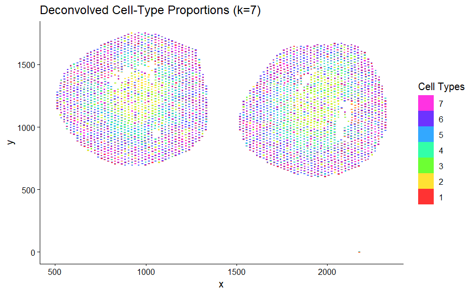

```r
#opting for K = 7
optLDA_hour12 <- optimalModel(models = ldas_hour12, opt = "7")

#extract deconvolved cell-type proportions (theta) and transcriptional profiles (beta)
results_hour12 <- getBetaTheta(optLDA_hour12, perc.filt = 0.05, betaScale = 1000)
deconProp_hour12 <- results_hour12$theta  # Spots x cell types (clusters)
deconGexp_hour12 <- results_hour12$beta   # Genes x cell types (clusters)


#scatterbar to create a scattered stacked bar chart
p_deconvolve_hour12 <- scatterbar(
  data         = as.data.frame(deconProp_hour12),
  xy           = pos_hour12,
  size_x       = 10,       # adjust to control bar width in x dimension
  size_y       = 10,       # adjust to control bar height in y dimension
  padding_x    = 0.01,     # add some padding to the x axis
  padding_y    = 0.01,     # add some padding to the y axis
  show_legend  = TRUE,
  legend_title = "Cell Types",
  verbose      = TRUE) +
  labs(x = "x", y = "y") +
  ggtitle("Deconvolved Cell-Type Proportions (k=7)") +
  theme_classic()

p_deconvolve_hour12
```

```
now fitting LDA model with K = 7
computing perplexity for LDA model with K = 7
```

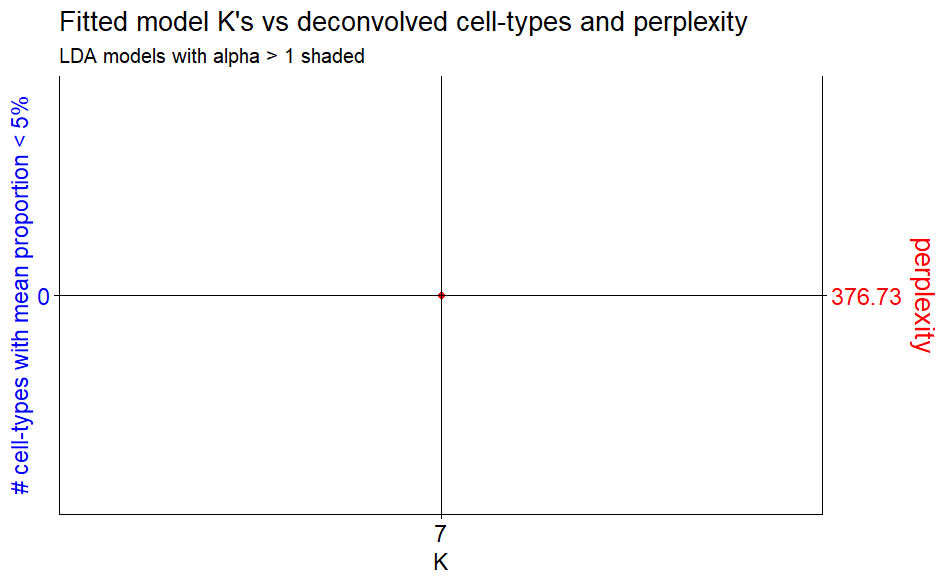

```r
#fit LDA models across a range of K values (number of cell types)
#fitLDA expects spots in rows and genes in columns, so we transpose corpus.
ldas_hour4 <- fitLDA(t(as.matrix(corpus_hour4)), Ks = 7)
```

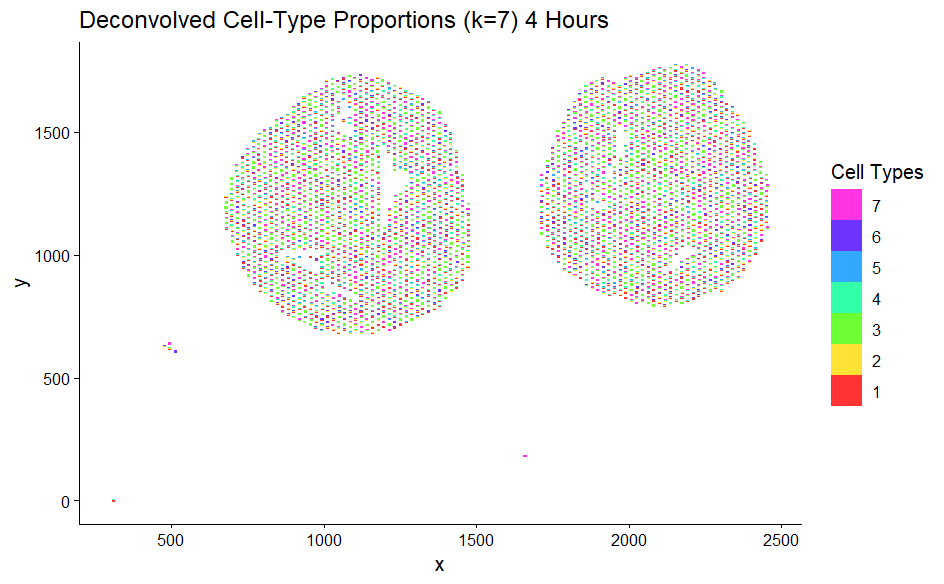

```r
#opting for K = 7
optLDA_hour4 <- optimalModel(models = ldas_hour4, opt = "7")

#extract deconvolved cell-type proportions (theta) and transcriptional profiles (beta)
results_hour4 <- getBetaTheta(optLDA_hour4, perc.filt = 0.05, betaScale = 1000)
deconProp_hour4 <- results_hour4$theta  # Spots x cell types (clusters)
deconGexp_hour4 <- results_hour4$beta   # Genes x cell types (clusters)


#scatterbar to create a scattered stacked bar chart
p_deconvolve_hour4 <- scatterbar(
  data         = as.data.frame(deconProp_hour4),
  xy           = pos_hour4,
  size_x       = 10,       # adjust to control bar width in x dimension
  size_y       = 10,       # adjust to control bar height in y dimension
  padding_x    = 0.01,     # add some padding to the x axis
  padding_y    = 0.01,     # add some padding to the y axis
  show_legend  = TRUE,
  legend_title = "Cell Types",
  verbose      = TRUE) +
  labs(x = "x", y = "y") +
  ggtitle("Deconvolved Cell-Type Proportions (k=7) 4 Hours") +
  theme_classic()

p_deconvolve_hour4
```

```r
#I got this from https://humphreyslab.com/SingleCell/
markers <- list(
  Pod= c('Podxl','Nphs2','Sema3g','Cdkn1c','Rhpn1','Ptpro','Synpo','Sparc','Ccn2','Vim'),
  PTs12= c('Cyp4a14','Slc34a1','Slc13a3','Gpx3','Miox','Aldob','Acaa1b','Slc22a8','Slc22a6','Pck1'),
  PTs3= c('Serpina1f','Cyp2a4','Slc22a19','Akr1c18','Scd1','Slc22a7','Aadat','Kap','Napsa','Lrp2'),
  PTs3_TAL= c('Kap','Serpina1f','Napsa','Scd1','Umod','Aadat','Slc22a7','Havcr1','S100a8','Lgals1'),
  TAL= c('Umod','Slc12a1','Clcnka','Slc14a2','Cd24a','Tspan8','Cldn10','Lcn2','Ckb','Ppp1r1a'),
  DTL= c('Aqp1','Slc14a2','Tinagl1','Akap12','Thbs1','Gprc5a','Nupr1','S100a6','Hspb1','Ifit3'),
  DCT= c('Slc12a3','Pvalb','Calb1','Clcnkb','Klk1','S100g','Slc8a1','Kl','Wnk4','Defb1'),
  PC= c('Aqp2','Muc20','Psca','Wnt7b','Fxyd4','Krt18','Muc1','Gstm2','Akr1b3','Bcam'),
  IC= c('Atp6v1g3','Rhbg','Slc26a4','Rhcg','Hsd11b2','Clu','Car15','Tacstd2','Cldn4','Scnn1b'),
  Uro= c('Upk3a','Upk1a','Upk1b','Upk2','Krt15','Krt5','Krt18','Krt19','Ly6d','Msln'),
  Fib= c('Dcn','Col1a1','Col1a2','Col3a1','Acta2','Myh11','Eln','Bgn','Tagln','Myl9'),
  Immune= c('Lyz2','Ctss','Cd52','Tyrobp','C1qc','C1qa','C1qb','Apoe','Cfh','Cd74', 'Cd68', 'Il6'))
```

```r
score_topics <- function(beta_matrix, marker_list) {
  # beta_matrix: topics x genes (rows = topics, cols = genes)
  scores <- sapply(marker_list, function(genes) {
    genes_present <- intersect(genes, colnames(beta_matrix))  # genes are in COLUMNS
    if (length(genes_present) == 0) return(rep(0, nrow(beta_matrix)))
      # average across marker genes per topic
    rowMeans(beta_matrix[, genes_present, drop = F])})
  return(as.data.frame(scores))  # topics x cell_types
}
```

```r
annotate_topics <- function(deconGexp, deconProp, condition_name, pos, corpus) {

  #align rownames using corpus barcodes
  barcodes <- colnames(corpus)
  pos <- as.data.frame(pos)
  colnames(pos) <- c('x', 'y')

  n <- min(nrow(pos), nrow(deconProp))

  pos_aligned<- pos[1:n, ]
  deconProp_aligned <- deconProp[1:n, ]
  spot_ids<- barcodes[1:n]

  rownames(pos_aligned)<- spot_ids
  rownames(deconProp_aligned)<- spot_ids


  #score topics against marker lists
  topic_scores <- score_topics(deconGexp, markers)
  rownames(topic_scores) <- rownames(deconGexp)

  cat('\nMax marker score per topic:\n')
  print(round(apply(topic_scores, 1, max), 4))

  #assign cell types based on max score
  best_match <- apply(topic_scores, 1, function(x) {
    if (all(x == 0)) return('Unassigned')
    names(which.max(x))})
  #I wanted to make it unique because there might be a reason why STdeconvolve
  #seperated the clusters
  #they could be more injured cells compared to the other cluster
  best_match_unique <- make.unique(best_match, sep = '_')

  cat('\nCell type assignments for', condition_name, '\n')
  print(data.frame(Topic=rownames(topic_scores),
                   CellType=best_match,
                   UniqueLabel = best_match_unique))

  #create a heatmap of the topics scores
  topic_scores_clean <- topic_scores[rowSums(topic_scores) > 0, , drop = F]

  if (nrow(topic_scores_clean) > 1) {
    pheatmap::pheatmap(topic_scores_clean,
                       scale= 'row',
                       cluster_rows = F,
                       main= paste('Topic–Cell Type Scores:', condition_name),
                       angle_col= 45,)}

  #rename deconProp columns
  deconProp_named <- deconProp_aligned
  colnames(deconProp_named) <- best_match_unique

  #remake the scatterbar plot but with the annotation labels
  p <- scatterbar(
    data         = as.data.frame(deconProp_named),
    xy           = pos_aligned,
    size_x       = 10,
    size_y       = 10,
    padding_x    = 0.01,
    padding_y    = 0.01,
    show_legend  = T,
    legend_title = 'Cell Types',
    verbose      = T) +
    labs(x = 'X', y = 'Y') +
    ggtitle(paste('Deconvolved Cell-Type Proportions:', condition_name)) +
    theme_classic()

  return(list(scores= topic_scores,
              assignments= best_match_unique,
              deconProp_named = deconProp_named,
              pos_aligned= pos_aligned,
              plot = p))}
```

```r
# ── 0. Marker gene lists ───────────────────────────────────────────────────────
markers <- list(
  Pod      = c("Podxl","Nphs2","Sema3g","Cdkn1c","Rhpn1","Ptpro","Synpo","Sparc","Ccn2","Vim"),
  PTs12    = c("Cyp4a14","Slc34a1","Slc13a3","Gpx3","Miox","Aldob","Acaa1b","Slc22a8","Slc22a6","Pck1"),
  PTs3     = c("Serpina1f","Cyp2a4","Slc22a19","Akr1c18","Scd1","Slc22a7","Aadat","Kap","Napsa","Lrp2"),
  PTs3_TAL = c("Kap","Serpina1f","Napsa","Scd1","Umod","Aadat","Slc22a7","Havcr1","S100a8","Lgals1"),
  TAL      = c("Umod","Slc12a1","Clcnka","Slc14a2","Cd24a","Tspan8","Cldn10","Lcn2","Ckb","Ppp1r1a"),
  DTL      = c("Aqp1","Slc14a2","Tinagl1","Akap12","Thbs1","Gprc5a","Nupr1","S100a6","Hspb1","Ifit3"),
  DCT      = c("Slc12a3","Pvalb","Calb1","Clcnkb","Klk1","S100g","Slc8a1","Kl","Wnk4","Defb1"),
  PC       = c("Aqp2","Muc20","Psca","Wnt7b","Fxyd4","Krt18","Muc1","Gstm2","Akr1b3","Bcam"),
  IC       = c("Atp6v1g3","Rhbg","Slc26a4","Rhcg","Hsd11b2","Clu","Car15","Tacstd2","Cldn4","Scnn1b"),
  Uro      = c("Upk3a","Upk1a","Upk1b","Upk2","Krt15","Krt5","Krt18","Krt19","Ly6d","Msln"),
  Fib      = c("Dcn","Col1a1","Col1a2","Col3a1","Acta2","Myh11","Eln","Bgn","Tagln","Myl9"),
  Immune   = c("Lyz2","Ctss","Cd52","Tyrobp","C1qc","C1qa","C1qb","Apoe","Cfh","Cd74", "Cd68", "Il6")
)

# ── Fix score_topics: beta is TOPICS x GENES ──────────────────────────────────
score_topics <- function(beta_matrix, marker_list) {
  # beta_matrix: topics x genes (rows = topics, cols = genes)
  scores <- sapply(marker_list, function(genes) {
    genes_present <- intersect(genes, colnames(beta_matrix))  # genes are in COLUMNS
    if (length(genes_present) == 0) return(rep(0, nrow(beta_matrix)))
    rowMeans(beta_matrix[, genes_present, drop = FALSE])       # average across marker genes per topic
  })
  return(as.data.frame(scores))  # topics x cell_types
}

annotate_topics <- function(deconGexp, deconProp, condition_name, pos, corpus) {

  # ── 1. Align rownames using corpus barcodes ───────────────────────────────
  barcodes <- colnames(corpus)

  pos <- as.data.frame(pos)
  colnames(pos) <- c("x", "y")

  n <- min(nrow(pos), nrow(deconProp))

  pos_aligned       <- pos[1:n, ]
  deconProp_aligned <- deconProp[1:n, ]
  spot_ids          <- barcodes[1:n]

  rownames(pos_aligned)       <- spot_ids
  rownames(deconProp_aligned) <- spot_ids

  cat("\n── Dimensions check for", condition_name, "──\n")
  cat("deconGexp:", nrow(deconGexp), "topics x", ncol(deconGexp), "genes\n")
  cat("deconProp:", nrow(deconProp_aligned), "spots x", ncol(deconProp_aligned), "topics\n")
  cat("pos:      ", nrow(pos_aligned), "spots\n")

  # ── 2. Score topics against marker lists ──────────────────────────────────
  topic_scores <- score_topics(deconGexp, markers)
  rownames(topic_scores) <- rownames(deconGexp)

  cat("\nMax marker score per topic:\n")
  print(round(apply(topic_scores, 1, max), 4))

  # ── 3. Assign cell types ──────────────────────────────────────────────────
  best_match <- apply(topic_scores, 1, function(x) {
    if (all(x == 0)) return("Unassigned")
    names(which.max(x))
  })
  best_match_unique <- make.unique(best_match, sep = "_")

  cat("\n── Cell type assignments for", condition_name, "──\n")
  print(data.frame(
    Topic       = rownames(topic_scores),
    CellType    = best_match,
    UniqueLabel = best_match_unique
  ))

  # ── 4. Heatmap ────────────────────────────────────────────────────────────
  topic_scores_clean <- topic_scores[rowSums(topic_scores) > 0, , drop = FALSE]

  if (nrow(topic_scores_clean) > 1) {
    pheatmap::pheatmap(
      topic_scores_clean,
      scale        = "row",
      cluster_rows = FALSE,
      main         = paste("Topic–Cell Type Scores:", condition_name),
      angle_col    = 45,
      filename     = paste0("heatmap_", condition_name, ".pdf")
    )
  }

  # ── 5. Rename deconProp columns ───────────────────────────────────────────
  deconProp_named <- deconProp_aligned
  colnames(deconProp_named) <- best_match_unique

  # ── 6. Scatterbar plot ────────────────────────────────────────────────────
  p <- scatterbar(
    data         = as.data.frame(deconProp_named),
    xy           = pos_aligned,
    size_x       = 10,
    size_y       = 10,
    padding_x    = 0.01,
    padding_y    = 0.01,
    show_legend  = TRUE,
    legend_title = "Cell Types",
    verbose      = TRUE
  ) +
    labs(x = "X", y = "Y") +
    ggtitle(paste("Deconvolved Cell-Type Proportions:", condition_name)) +
    theme_classic()

  return(list(
    scores          = topic_scores,
    assignments     = best_match_unique,
    deconProp_named = deconProp_named,
    pos_aligned     = pos_aligned,       # returning aligned pos for downstream use
    plot            = p
  ))
}

# ── Run for all three conditions ──────────────────────────────────────────────
res_sham   <- annotate_topics(deconGexp_sham,   deconProp_sham,   "Sham", pos_sham,   corpus_sham)
```

```
── Dimensions check for Sham ──
deconGexp: 7 topics x 810 genes
deconProp: 2857 spots x 7 topics
pos:       2857 spots

Max marker score per topic:
      1       2       3       4       5       6       7
 6.4139  6.5833  2.7573 32.8889 15.9763 25.4027 17.7824

── Cell type assignments for Sham ──
  Topic CellType UniqueLabel
1     1   Immune      Immune
2     2    PTs12       PTs12
3     3     PTs3        PTs3
4     4 PTs3_TAL    PTs3_TAL
5     5    PTs12     PTs12_1
6     6      DCT         DCT
7     7    PTs12     PTs12_2
```

```r
res_hour4  <- annotate_topics(deconGexp_hour4,  deconProp_hour4,  "4h",   pos_hour4,  corpus_hour4)
```

```
── Dimensions check for 4h ──
deconGexp: 7 topics x 1000 genes
deconProp: 3085 spots x 7 topics
pos:       3085 spots

Max marker score per topic:
      1       2       3       4       5       6       7
 7.3678  7.3025 10.4707 13.0718  8.3718 35.0614  2.8228

── Cell type assignments for 4h ──
  Topic CellType UniqueLabel
1     1    PTs12       PTs12
2     2    PTs12     PTs12_1
3     3      TAL         TAL
4     4    PTs12     PTs12_2
5     5   Immune      Immune
6     6      DCT         DCT
7     7     PTs3        PTs3
```

```r
res_hour12 <- annotate_topics(deconGexp_hour12, deconProp_hour12, "12h",  pos_hour12, corpus_hour12)
```

```
── Dimensions check for 12h ──
deconGexp: 7 topics x 1000 genes
deconProp: 3392 spots x 7 topics
pos:       3392 spots

Max marker score per topic:
      1       2       3       4       5       6       7
 3.9726  9.2587 34.4503  4.5137 20.8765 13.5828 26.4732

── Cell type assignments for 12h ──
  Topic CellType UniqueLabel
1     1    PTs12       PTs12
2     2      TAL         TAL
3     3      TAL       TAL_1
4     4 PTs3_TAL    PTs3_TAL
5     5 PTs3_TAL  PTs3_TAL_1
6     6    PTs12     PTs12_1
7     7      DCT         DCT
```

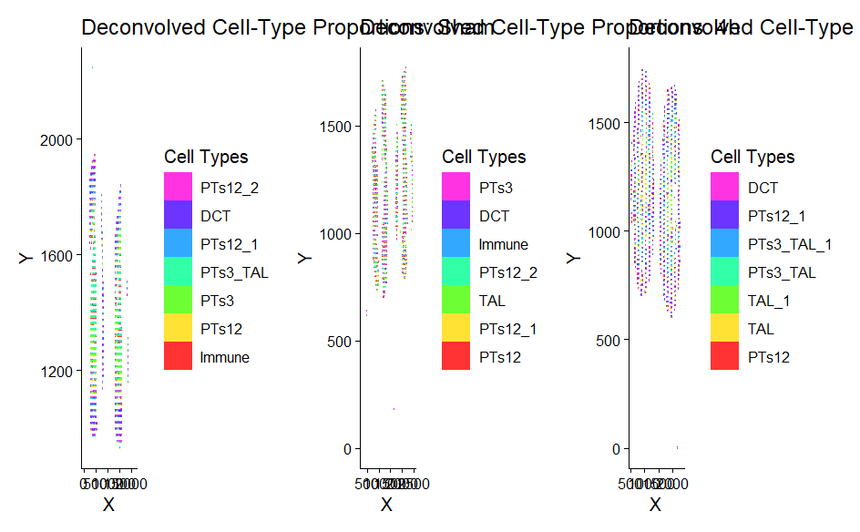

```r
# ── View plots ────────────────────────────────────────────────────────────────
res_sham$plot | res_hour4$plot | res_hour12$plot
```

```r
#heatmap of average marker gene expression
plot_avg_marker_heatmap <- function(deconGexp, res_obj, condition_name, markers) {

  # deconGexp: topics x genes matrix
  # res_obj: result from annotate_topics (contains assignments)
  #get the cell type assignments for each topic
  topic_assignments <- res_obj$assignments
  names(topic_assignments) <- rownames(deconGexp)


  #get all unique cell types in your markers list
  all_cell_types <- names(markers)

  #matrix to store average expression for each topic vs each cell type
  avg_expr_matrix <- matrix(0, nrow=nrow(deconGexp), ncol=length(all_cell_types))
  rownames(avg_expr_matrix) <- rownames(deconGexp)
  colnames(avg_expr_matrix) <- all_cell_types

  #for each topic, calculate average expression of markers for each cell type
  for (i in 1:nrow(deconGexp)) {
    topic_name <- rownames(deconGexp)[i]

    for (j in 1:length(all_cell_types)) {
      cell_type <- all_cell_types[j]
      marker_genes <- markers[[cell_type]]

      #find which marker genes are present in the gene expression matrix
      genes_present <- intersect(marker_genes, colnames(deconGexp))

      if (length(genes_present) > 0) {
        #average expression of these marker genes for this topic
        avg_expr_matrix[i, j] <- mean(deconGexp[topic_name, genes_present])}
    }
  }

  #scale each row
  avg_expr_scaled <- t(scale(t(avg_expr_matrix)))

  #annotation for topics
  topic_annotation <- data.frame(
    Assigned_CellType = factor(topic_assignments[rownames(avg_expr_scaled)]))
  rownames(topic_annotation) <- rownames(avg_expr_scaled)

  # Create annotation colors
  #get number of cell types and create colors exactly like scatterbar
  cell_types_in_annotation <- levels(topic_annotation$Assigned_CellType)
  n_celltypes_anno <- length(cell_types_in_annotation)

  #create colors using same method as scatterbar
  celltype_colors <- rainbow(n_celltypes_anno)
  names(celltype_colors) <- cell_types_in_annotation


  #https://www.rdocumentation.org/packages/pheatmap/versions/1.0.13/topics/pheatmap
  p<- pheatmap::pheatmap(
    avg_expr_scaled,
    cluster_rows = F,
    cluster_cols = F,
    main = paste('Average Marker Expression -', condition_name),
    annotation_row = data.frame(
      CellType = factor(topic_assignments[rownames(avg_expr_scaled)])),
    annotation_colors = list(
      CellType = celltype_colors[unique(topic_assignments)]),
    color = colorRampPalette(c('navy', 'white', 'firebrick3'))(100),
    display_numbers = T,
    width = 10,
    height = 6)

  # Also create a simpler version with topic labels including assignments
  rownames_clean <- paste0(rownames(avg_expr_scaled), ' (', topic_assignments, ')')
  avg_expr_named <- avg_expr_scaled
  rownames(avg_expr_named) <- rownames_clean

  return(list(avg_matrix = avg_expr_matrix,
              avg_scaled = avg_expr_scaled,
              topic_assignments = topic_assignments,
              plot = p))
}
```

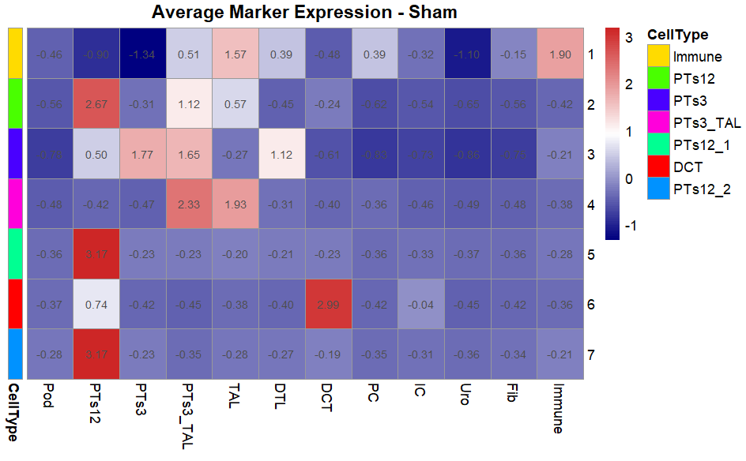

```r
avg_sham   <- plot_avg_marker_heatmap(deconGexp_sham, res_sham, 'Sham', markers)
```

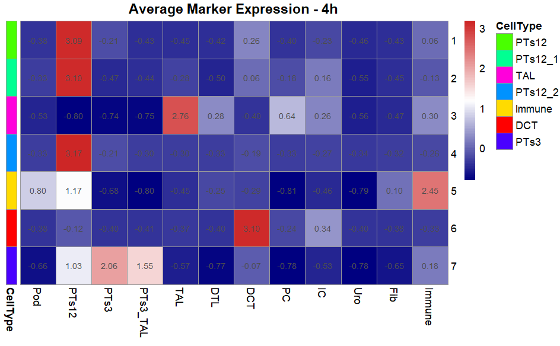

```r
avg_hour4  <- plot_avg_marker_heatmap(deconGexp_hour4, res_hour4, '4h', markers)
```

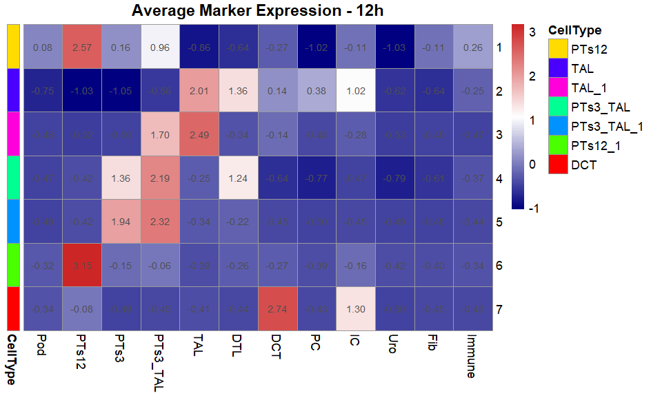

```r
avg_hour12 <- plot_avg_marker_heatmap(deconGexp_hour12, res_hour12, '12h', markers)
```

```r
#compute mean proportion per cell type for each condition ────────────────
get_mean_props <- function(deconProp_named, condition) {
  as.data.frame(deconProp_named) %>%
    summarise(across(everything(), mean)) %>%
    pivot_longer(everything(), names_to = 'CellType', values_to = 'Proportion') %>%
    mutate(Condition = condition)
}

df_sham<- get_mean_props(res_sham$deconProp_named,   'Sham')
df_hour4<- get_mean_props(res_hour4$deconProp_named,  '4h')
df_hour12<- get_mean_props(res_hour12$deconProp_named, '12h')

all_cell_types <- unique(c(
  unique(df_sham$CellType),
  unique(df_hour4$CellType),
  unique(df_hour12$CellType)
))

#make a complete grid of all conditions and cell types
df_all <- expand.grid(Condition = c('Sham', '4h', '12h'),
                      CellType = all_cell_types,
                      stringsAsFactors = F) %>%
                      left_join(
                        bind_rows(df_sham, df_hour4, df_hour12),
                        by = c('Condition', 'CellType')) %>%
                      #replace NA with 0
                      mutate(
                        Proportion = ifelse(is.na(Proportion), 0, Proportion),
                        Condition = factor(Condition, levels = c('Sham', '4h', '12h')))

ggplot(df_all, aes(x = CellType, y = Proportion, fill = Condition)) +
  geom_bar(stat = 'identity', position = position_dodge(width = 0.8), width = 0.7) +
  scale_fill_manual(values = c('Sham' = 'green', '4h' = 'orange', '12h' = 'purple')) +
  labs(title = 'Cell type proportions: Sham vs 4h vs 12h',
       x= 'Cell Type',
       y= 'Mean Proportion',
       fill= 'Condition') +
  theme_classic() +
  theme(axis.text.x  = element_text(angle = 45, hjust = 1),
        plot.title   = element_text(hjust = 0.5))+
  scale_y_continuous(expand = c(0, 0)) +
  coord_cartesian(ylim=c(0, 0.4))+
  theme(plot.title = element_text(face = "bold", size = 12, hjust = 0.5))
```

[output not shown]

```r
cortex_types  <- c('Pod', 'PTs12', 'PTs3', 'PTs3_TAL', 'DCT')
medulla_types <- c('TAL', 'DTL', 'PC', 'IC')

estimate_cmj <- function(deconProp_named, pos) {
  df <- as.data.frame(deconProp_named)

  #find which cortex-specific and medulla-specific cell types exist in our data
  #cortex_types and medulla_types should be defined globally with lists of cell type names
  cortex_cols  <- intersect(cortex_types,  colnames(df))
  medulla_cols <- intersect(medulla_types, colnames(df))

  cat('  Cortex cell types found: ', paste(cortex_cols,  collapse=', '), '\n')
  cat('  Medulla cell types found:', paste(medulla_cols, collapse=', '), '\n')


  #for each spot, calculate the average proportion of cortex-specific cell types
  #If no cortex types exist, set score to 0
  df$cortex_score  <- if (length(cortex_cols)  > 0) {
    rowMeans(df[, cortex_cols, drop = F]) } else {0}

  #for each spot, calculate the average proportion of medulla-specific cell types
  # If no medulla types exist, set score to 0
  df$medulla_score <- if (length(medulla_cols) > 0) {
    rowMeans(df[, medulla_cols, drop = F])} else {0}

  #a spot belongs to cortex if its cortex_score is higher than medulla_score
  df$region <- ifelse(df$cortex_score > df$medulla_score, 'cortex', 'medulla')

  #Y-coordinate from position data (assuming Y-axis runs from cortex to medulla)
  df$y <- as.data.frame(pos)[, 2]

  #num spots were classified into each region
  n_cortex<- sum(df$region == 'cortex')
  n_medulla<- sum(df$region == 'medulla')
  cat('  Spots classified as cortex: ', n_cortex, '\n')
  cat('  Spots classified as medulla:', n_medulla, '\n')

  # The CMJ is the boundary where cortex ends and medulla begins
  #we find the lowest cortex spot (maximum Y) and highest medulla spot (minimum Y)
  #I assume that the CMJ is the midpoint between these two

  if (n_medulla == 0) {
    #No medulla spots detected (possible if section is all cortex)
    cat('No medulla spots found; using median Y as CMJ estimate\n')
    #use median Y coordinate
    cmj_y <- median(df$y)}
  else if (n_cortex == 0) {
    #case 2: No cortex spots detected (possible if section is all medulla)
    cat('No cortex spots found; using median Y as CMJ estimate\n')
    cmj_y <- median(df$y)}
  else {
    #Case 3: Both regions present, calculate T boundary
    #we find the lowest cortex spot. This is the last cortex before medulla
    max_cortex_y  <- max(df$y[df$region == 'cortex'])
    #highest medulla spot is the first medulla after cortex
    min_medulla_y <- min(df$y[df$region == 'medulla'])
    #CMJ is the average of these two boundary points
    cmj_y <- mean(c(max_cortex_y, min_medulla_y))}

  cat('  Estimated CMJ Y coordinate:', cmj_y, '\n')


  return(list(cmj_y = cmj_y, df = df))}

prep_cmj_df <- function(deconProp_named, pos, cmj_y, condition, counts, macro_markers) {

  df <- as.data.frame(deconProp_named)

  #macrophage markers present in this condition's counts
  markers_present <- intersect(macro_markers, rownames(counts))

  #mean expression of macrophage markers per spot
  macro_expr <- counts[markers_present, 1:nrow(df), drop = FALSE]
  df$macro_loading <- colMeans(macro_expr)

  df %>%
    mutate(dist_CMJ  = pos[, 2] - cmj_y, Condition = condition) %>%
    dplyr::select(dist_CMJ, macro_loading, Condition)
}
```

```r
cmj_sham<- estimate_cmj(res_sham$deconProp_named,   res_sham$pos_aligned)
```

```
  Cortex cell types found:  PTs12, PTs3, PTs3_TAL, DCT
  Medulla cell types found:
  Spots classified as cortex:  2825
  Spots classified as medulla: 32
  Estimated CMJ Y coordinate: 1599.5
```

```r
cmj_hour4<- estimate_cmj(res_hour4$deconProp_named,  res_hour4$pos_aligned)
```

```
  Cortex cell types found:  PTs12, PTs3, DCT
  Medulla cell types found: TAL
  Spots classified as cortex:  2321
  Spots classified as medulla: 764
  Estimated CMJ Y coordinate: 1232
```

```r
cmj_hour12<- estimate_cmj(res_hour12$deconProp_named, res_hour12$pos_aligned)
```

```
  Cortex cell types found:  PTs12, PTs3_TAL, DCT
  Medulla cell types found: TAL
  Spots classified as cortex:  2369
  Spots classified as medulla: 1023
  Estimated CMJ Y coordinate: 876
```

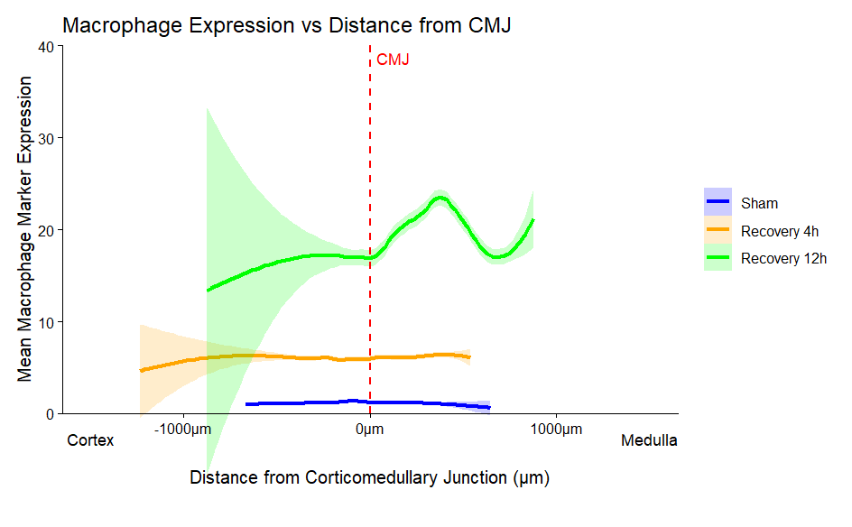

```r
#https://www.rndsystems.com/resources/cell-markers/immune-cells/macrophages/macrophage-common-markers
#https://www.antibodies.com/primary-antibodies/cell-markers/immune-cell-markers/macrophage-markers
macro_markers <- c('Lyz2','Ctss','Cd52','Tyrobp','C1qc','C1qa','C1qb',
                   'Apoe','Cfh','Cd74','Csf1r','Adgre1','Cx3cr1','Spp1', 'Cd68')

df_sham<- prep_cmj_df(res_sham$deconProp_named,
                      res_sham$pos_aligned,
                      cmj_sham$cmj_y,
                      'Sham',
                      counts_sham,
                      macro_markers)

df_hour4<- prep_cmj_df(res_hour4$deconProp_named,
                       res_hour4$pos_aligned,
                       cmj_hour4$cmj_y,
                       'Recovery 4h',
                       counts_hour4,
                       macro_markers)

df_hour12<- prep_cmj_df(res_hour12$deconProp_named,
                        res_hour12$pos_aligned,
                        cmj_hour12$cmj_y,
                        'Recovery 12h',
                        counts_hour12,
                        macro_markers)

df_all <- bind_rows(df_sham, df_hour4, df_hour12) %>%
  mutate(Condition = factor(Condition, levels = c('Sham', 'Recovery 4h', 'Recovery 12h')))

condition_colors <- c('Sham' = 'blue', 'Recovery 4h'= 'orange', 'Recovery 12h' = 'green')

ggplot(df_all, aes(x = dist_CMJ, y = macro_loading, color = Condition, fill = Condition)) +
  geom_smooth(method = 'loess', span = 0.4, se = T, alpha = 0.2, linewidth = 1.2) +
  geom_vline(xintercept = 0, linetype = 'dashed', color = 'red', linewidth = 0.6) +
  annotate('text', x = 0, y = Inf, label = 'CMJ', color = 'red',
           vjust = 1.5, hjust = -0.2, size = 3.5) +
  annotate('text', x = -1500, y = -Inf, label = 'Cortex',
           color = 'black', vjust = 2.5, size = 3.5) +
  annotate('text', x = 1500, y = -Inf, label = 'Medulla',
           color = 'black', vjust = 2.5, size = 3.5) +
  scale_color_manual(values = condition_colors) +
  scale_fill_manual(values  = condition_colors) +
  scale_x_continuous(breaks = seq(-2000, 3000, by = 1000),
                     labels = paste0(seq(-2000, 3000, by = 1000), 'µm')) +
  coord_cartesian(clip = 'off') +
  labs(title = 'Macrophage Expression vs Distance from CMJ',
    x = 'Distance from Corticomedullary Junction (µm)',
    y     = 'Mean Macrophage Marker Expression',
    color = NULL, fill = NULL
  ) +
  scale_y_continuous(expand = c(0, 0)) +
  coord_cartesian(ylim=c(0, 40), clip = 'off')+
  theme_classic()+
  theme(plot.margin      = margin(10, 10, 25, 10),
  axis.title.x     = element_text(margin = margin(t = 20)),)
```

```r
get_macro_score <- function(counts, deconProp_named) {
  n <- nrow(deconProp_named)
  #macrophage markers actually present in our count data
  markers_present <- intersect(macro_markers, rownames(counts))
  cat('Markers found:', paste(markers_present, collapse = ', '), '\n')
  #mean expression across all macrophage markers for each spot
  #if only 1 marker found, just return that one marker's expression
  macro_expr<- as.matrix(counts[markers_present, 1:n, drop = F])
  if (nrow(macro_expr) == 1) as.numeric(macro_expr[1, ]) else colMeans(macro_expr)
}

macro_sham   <- get_macro_score(counts_sham,   res_sham$deconProp_named)
```

```
Markers found: Lyz2, Ctss, Cd52, Tyrobp, C1qc, C1qa, C1qb, Apoe, Cfh, Cd74, Csf1r, Adgre1, Cx3cr1, Spp1, Cd68
```

```r
macro_hour4  <- get_macro_score(counts_hour4,  res_hour4$deconProp_named)
```

```
Markers found: Lyz2, Ctss, Cd52, Tyrobp, C1qc, C1qa, C1qb, Apoe, Cfh, Cd74, Csf1r, Adgre1, Cx3cr1, Spp1, Cd68
```

```r
macro_hour12 <- get_macro_score(counts_hour12, res_hour12$deconProp_named)
```

```
Markers found: Lyz2, Ctss, Cd52, Tyrobp, C1qc, C1qa, C1qb, Apoe, Cfh, Cd74, Csf1r, Adgre1, Cx3cr1, Spp1, Cd68
```

[figure not shown]

```r
#correlate macrophage score with each cell type proportion
correlate_with_macro <- function(deconProp_named, macro_score, condition) {

  df <- as.data.frame(deconProp_named)

  cor_results <- sapply(colnames(df), function(ct) {cor(df[[ct]], macro_score, method = 'spearman')})

  data.frame(CellType = names(cor_results),
            Spearman_r = cor_results,
            Condition = condition) %>%
            arrange(desc(Spearman_r))}

cor_sham <- correlate_with_macro(res_sham$deconProp_named,   macro_sham,   'Sham')
cor_hour4 <- correlate_with_macro(res_hour4$deconProp_named,  macro_hour4,  '4h')
cor_hour12 <- correlate_with_macro(res_hour12$deconProp_named, macro_hour12, '12h')


df_all <- bind_rows(cor_sham, cor_hour4, cor_hour12) %>%
  mutate(Condition = factor(Condition, levels = c('Sham', '4h', '12h')))

ggplot(df_all, aes(x = reorder(CellType, Spearman_r), y = Spearman_r, fill = Spearman_r > 0)) +
  geom_bar(stat = 'identity', width = 0.7) +
  geom_hline(yintercept = 0, linetype = 'dashed', color = 'black') +
  scale_fill_manual(values = c('TRUE' = '#E74C3C', 'FALSE' = '#3498DB'), guide = 'none') +
  facet_wrap(~ Condition, ncol = 3) +
  coord_flip() +
  labs(title = 'Correlation of cell type proportion with macrophage marker expression',
       x = NULL,
       y = 'Spearman correlation') +
  theme_classic() +
  theme(plot.title  = element_text(hjust = 0.5, size = 11),
        strip.text  = element_text(size = 11, face = 'bold'),
        axis.text.y = element_text(size = 10))
```

```r
#scatter plot for top correlated cell type in 12h
top_ct_12h <- cor_hour12$CellType[1]
cat('\nTop correlated cell type in 12h:', top_ct_12h, '\n')
```

[output not shown]

[figure not shown]

```r
df_scatter <- data.frame(macro_score = macro_hour12, ct_prop = res_hour12$deconProp_named[, top_ct_12h])

ggplot(df_scatter, aes(x = ct_prop, y = macro_score)) +
  geom_point(alpha = 0.3, size = 0.8, color = '#E74C3C') +
  geom_smooth(method = 'lm', color = 'black', linewidth = 0.8) +
  labs(title = paste('Macrophage score vs', top_ct_12h, 'proportion (12h)'),
       x = paste(top_ct_12h, 'topic proportion'),
       y = 'Mean macrophage marker expression') +
  theme_classic() +
  theme(plot.title = element_text(hjust = 0.5))
```

```r
get_macro_score <- function(counts, deconProp_named) {
  n <- nrow(deconProp_named)
  #macrophage markers actually present in our count data
  markers_present <- intersect(macro_markers, rownames(counts))
  cat('Markers found:', paste(markers_present, collapse = ', '), '\n')
  #mean expression across all macrophage markers for each spot
  #if only 1 marker found, just return that one marker's expression
  macro_expr<- as.matrix(counts[markers_present, 1:n, drop = F])
  if (nrow(macro_expr) == 1) as.numeric(macro_expr[1, ]) else colMeans(macro_expr)
}

macro_sham   <- get_macro_score(counts_sham,   res_sham$deconProp_named)
macro_hour4  <- get_macro_score(counts_hour4,  res_hour4$deconProp_named)
macro_hour12 <- get_macro_score(counts_hour12, res_hour12$deconProp_named)

#correlate macrophage score with each cell type proportion
correlate_with_macro <- function(deconProp_named, macro_score, condition) {

  df <- as.data.frame(deconProp_named)

  cor_results <- sapply(colnames(df), function(ct) {cor(df[[ct]], macro_score, method = 'spearman')})

  data.frame(CellType = names(cor_results),
            Spearman_r = cor_results,
            Condition = condition) %>%
            arrange(desc(Spearman_r))}

cor_sham <- correlate_with_macro(res_sham$deconProp_named,   macro_sham,   'Sham')
cor_hour4 <- correlate_with_macro(res_hour4$deconProp_named,  macro_hour4,  '4h')
cor_hour12 <- correlate_with_macro(res_hour12$deconProp_named, macro_hour12, '12h')


df_all <- bind_rows(cor_sham, cor_hour4, cor_hour12) %>%
  mutate(Condition = factor(Condition, levels = c('Sham', '4h', '12h')))

ggplot(df_all, aes(x = reorder(CellType, Spearman_r), y = Spearman_r, fill = Spearman_r > 0)) +
  geom_bar(stat = 'identity', width = 0.7) +
  geom_hline(yintercept = 0, linetype = 'dashed', color = 'black') +
  scale_fill_manual(values = c('TRUE' = '#E74C3C', 'FALSE' = '#3498DB'), guide = 'none') +
  facet_wrap(~ Condition, ncol = 3) +
  coord_flip() +
  labs(title = 'Correlation of cell type proportion with macrophage marker expression',
       x = NULL,
       y = 'Spearman correlation') +
  theme_classic() +
  theme(plot.title = element_text(face = "bold", size = 12, hjust = 0.5),
        strip.text  = element_text(size = 11, face = 'bold'),
        axis.text.y = element_text(size = 10))

#scatter plot for top correlated cell type in 12h
top_ct_12h <- cor_hour12$CellType[1]
cat('\nTop correlated cell type in 12h:', top_ct_12h, '\n')

df_scatter <- data.frame(macro_score = macro_hour12, ct_prop = res_hour12$deconProp_named[, top_ct_12h])

ggplot(df_scatter, aes(x = ct_prop, y = macro_score)) +
  geom_point(alpha = 0.3, size = 0.8, color = '#E74C3C') +
  geom_smooth(method = 'lm', color = 'black', linewidth = 0.8) +
  labs(title = paste('Macrophage score vs', top_ct_12h, 'proportion (12h)'),
       x = paste(top_ct_12h, 'topic proportion'),
       y = 'Mean macrophage marker expression') +
  theme_classic() +
  theme(plot.title = element_text(face = "bold", size = 12, hjust = 0.5))
```

[output not shown]

```r
#get_top_genes: rows are topics, cols are genes
get_top_genes <- function(deconGexp, topic_row, n_genes = 100) {
  #topic_row is the numeric rowname
  topic_vec <- deconGexp[topic_row, ]
  top_genes <- names(sort(topic_vec, decreasing = T))[1:n_genes]
  return(top_genes)
}

#run_enrichment using topic number + cell type label
run_enrichment <- function(deconGexp, topic_row, cell_type_label,
                           n_genes = 100, condition_name = '') {

  top_genes <- get_top_genes(deconGexp, topic_row, n_genes)
  #Following the turtorial below
  #https://bioinformatics.ccr.cancer.gov/docs/btep-coding-club/CC2023/FunctionalEnrich_clusterProfiler/
  #SYMBOL: Human-readable gene names
  #ENTREZID: NCBI's database IDs (required for KEGG and GO)
  #org.Mm.eg.db is the mouse annotation database
  entrez <- bitr(top_genes,
                 fromType= 'SYMBOL',
                 toType= 'ENTREZID',
                 OrgDb= org.Mm.eg.db)

  if (nrow(entrez) == 0) stop('No Entrez IDs found')

  #GO: what biological processes are over-represented
  #tests if gene list has more genes from certain GO terms than expected by chance
  ego <- enrichGO(gene= entrez$ENTREZID,
                  OrgDb = org.Mm.eg.db,
                  ont = 'BP',
                  pAdjustMethod = 'BH',
                  pvalueCutoff  = 0.05,
                  qvalueCutoff  = 0.05,
                  readable = T)

  #KEGG Pathway Enrichment Analysis
  #tests if genes are enriched in specific signaling/metabolic pathways
  ekegg <- enrichKEGG(gene = entrez$ENTREZID,
                      organism = 'mmu',
                      pAdjustMethod = 'BH',
                      pvalueCutoff  = 0.05)

  return(list(GO= ego,KEGG = ekegg, genes = top_genes, label = paste(condition_name, cell_type_label)))
}

run_all_enrichments <- function(deconGexp, deconProp_named, condition_name, n_genes = 100) {

  cell_type_labels <- colnames(deconProp_named)
  topic_rows <- rownames(deconGexp)

  #we assume that in the same order — topic 1 = label 1 etc.
  #lapply iterates over each index i from 1 to the number of cell types
  results <- lapply(seq_along(cell_type_labels), function(i) {
    topic_row <- topic_rows[i]
    cell_type_label <- cell_type_labels[i]
    cat('Running enrichment for:', condition_name, '-', cell_type_label,
        '(Topic', topic_row, ')\n')
    run_enrichment(deconGexp, topic_row, cell_type_label, n_genes, condition_name)})

  names(results) <- cell_type_labels
  return(results)
}

enrich_sham   <- run_all_enrichments(deconGexp_sham,   res_sham$deconProp_named,   'Sham')
enrich_hour4  <- run_all_enrichments(deconGexp_hour4,  res_hour4$deconProp_named,  '4h')
enrich_hour12 <- run_all_enrichments(deconGexp_hour12, res_hour12$deconProp_named, '12h')
```

[output not shown]

```r
plot_enrichment <- function(enrich_df, top_n = 10, title = NULL) {
  df <- enrich_df %>%
    arrange(p.adjust) %>%
    head(top_n) %>%
    mutate(log10p= -log10(p.adjust),
           Description = factor(Description, levels = rev(Description)))

  ggplot(df, aes(x = log10p, y = Description)) +
    geom_bar(stat = 'identity', fill = '#1f77b4', width = 0.7) +
    geom_vline(xintercept = -log10(0.05), linetype = 'dashed', color = 'red', linewidth = 0.5) +
    labs(title = title, x = '-log10(adjusted p-value)', y = NULL) +
    theme_minimal() +
    theme(plot.title = element_text(hjust = 0.5, size = 11),
          axis.text.y= element_text(size = 9),
          panel.grid.major.y = element_blank())
}

plot_all_topics <- function(enrich_results, result_type = 'GO') {
  for (topic in names(enrich_results)) {
    res <- enrich_results[[topic]]
    if (is.null(res)) {
      cat('Skipped (NULL):', topic, '\n')
      next}

    df <- as.data.frame(res[[result_type]])
    if (nrow(df) == 0) {
      cat('No significant terms for:', topic, '\n')
      next}

    p <- plot_enrichment(df, title = paste(result_type, ':', res$label))
    print(p)
    cat('Plotted:', topic, '\n')}
}
```